```python
# setting up jupyter
%matplotlib inline
import matplotlib as mpl
mpl.rcParams['figure.dpi'] = 300
mpl.rcParams['savefig.dpi'] = 300
```

# Example 2 - exploring the knockdown of Chd4 and Mcrs1

In this example, mESCs were treated with shChd4 and shMcrs1. The sequencing analysis could not reveal the direction of differentiation in these cells, hence the outcome of exploring differentiation bias unknown. This example features the use of the ranked bar plot and how to utilize the plot's return values.

We start by passing the input data to *samples*. DEseq2 analysis was conducted on the data to identify the differential genes. Together with the expression TSV file, we can initiate the samples:

```python
import DPre
s = DPre.samples(diff_genes = './knockdown_deseq_res',
                 expression = 'knockdown_expression.tsv',
                 ctrl = 'shLuc',
                 name = 'sh knockdown in mESCs',
                )
```

```
INFO-DPre _format_diff_genes:
Formatting differential genes from deseq2 files. 2 *.tsv files in ./knockdown_deseq_res:
Luc.vs.Chd4.all.tsv ... Luc.vs.Mcrs1.all.tsv


WARNING-DPre merge_files:
679 NaN values found and deleted in Luc.vs.Chd4.all.tsv

WARNING-DPre merge_files:
378 NaN values found and deleted in Luc.vs.Mcrs1.all.tsv



INFO-DPre _is_expr_diff_compatible:
diff. genes (2) has one element less than expression (3). An empty element `shLuc` (control) will be added to diff. genes.

ERROR-DPre _is_expr_diff_compatible:
diff. genes- and expression element names do not match:
  expression names diff. genes names  match
0           shChd4   Luc.vs.Chd4.all  False
1          shMcrs1  Luc.vs.Mcrs1.all  False
2            shLuc             shLuc   True
Rename elements in expression /diff. genes input files or override the diff. genes names by setting `override_namematcher` to True.
```

```
An exception has occurred, use %tb to see the full traceback.

SystemExit: 1
```

As desired, the log tells us that the control was added to *diff_genes* data to match the length of expression. However, the initiation failed due to non-matching names between the expression- and gene list data. Since the elements do align and only differ in their naming (see logs), we can override the gene list names with the *override_namematcher* argument:

```python
import DPre
s = DPre.samples(diff_genes = './knockdown_deseq_res',
                 expression = 'knockdown_expression.tsv',
                 ctrl = 'shLuc',
                 name = 'sh knockdown in mESCs',
                 override_namematcher = True,    # ignore mismatches between expression and gene list names, use with care
                )
```

```
INFO-DPre _format_diff_genes:
Formatting differential genes from deseq2 files. 2 *.tsv files in ./knockdown_deseq_res:
Luc.vs.Chd4.all.tsv ... Luc.vs.Mcrs1.all.tsv


WARNING-DPre merge_files:
679 NaN values found and deleted in Luc.vs.Chd4.all.tsv

WARNING-DPre merge_files:
378 NaN values found and deleted in Luc.vs.Mcrs1.all.tsv



INFO-DPre _is_expr_diff_compatible:
diff. genes (2) has one element less than expression (3). An empty element `shLuc` (control) will be added to diff. genes.

WARNING-DPre _is_expr_diff_compatible:
diff. genes names have been overriden by expression names. CAUTION: diff. genes- and expression names do not match for all elements:
  expression names diff. genes names  match
0           shChd4   Luc.vs.Chd4.all  False
1          shMcrs1  Luc.vs.Mcrs1.all  False
2            shLuc             shLuc   True
Make sure data aligns to avaid mislabeling!

INFO-DPre __init__:
Number of diff. genes:
         down   up
shChd4    479  390
shMcrs1   844  691
shLuc       0    0



INFO-DPre _log_init:
=|=|=|=|=|=|=|=|====INITIATION====|=|=|=|=|=|=|=|=|=
New samples-instance created: `sh knockdown in mESCs`
	samples (3):
		shChd4,
		shMcrs1,
		shLuc
	Detected genes: 15760, of which 2303 diff. genes
	Differential genes loaded: True
	Expression data loaded: True
	Control passed: shLuc
```

Create the 'mouse' reference targets instance:

```python
import DPre
t = DPre.preset_targets('mouse', preset_colors=True)
```

```
INFO-DPre preset_targets:
Default targets `mouse` created, name: `mouse lineages`, elements: 272



INFO-DPre plot_color_legend:
Color legend generated and saved at C:\Users\LOaLoA\Anaconda3\Lib\DPre\examples\example2_knockdown/mouse_color_legend.pdf
```

We first get an overview of the similarities using the *target_similarity_heatmap()*. For cross validation, we also run both the 'intersect' and 'euclid' metric:

```python
import DPre
# euclid overview
hm = t.target_similarity_heatmap(s,
                                 metric = 'euclid',
                                 hide_targetlabels = True,
                                 heatmap_width = .09,
                                 targetlabels_space = .8,
                                 pivot = True,
                                 filename = 'target_sim_euclid.png',
                                 )
# intersect overview
hm = t.target_similarity_heatmap(s,
                                 metric = 'intersect',
                                 hide_targetlabels = True,
                                 heatmap_width = .09,
                                 targetlabels_space= .8,
                                 pivot = True,
                                 filename = 'target_sim_intersect.png',
                                 )
```

[output not shown]

```
=|=|=|=|=|=|=|=|====PLOT====|=|=|=|=|=|=|=|=|=
INFO-DPre target_similarity_heatmap:
Plot: mouse lineages & sh knockdown in mESCs

INFO-DPre _check_args:
Arguments passed. Getting data now ...

INFO-DPre plot_detec_mgs_prop:
Detection of targets (mouse lineages) marker genes in samples data (sh knockdown in mESCs):
                                       n marker genes  detected in samples  proportion
up B cells CD19+                                  432                  146    0.337963
   B cell (active)                                323                  121    0.374613
   B cell (germinal center)                       354                  135    0.381356
   B cell (naive)                                 303                  117    0.386139
   B cells CD43-                                  405                  158    0.390123
   Spermatids (round)                            1295                  506    0.390734
   Spermatids (elongated)                        1280                  502    0.392188
   Spermatids                                    1502                  598    0.398136
   Testicular cells                              1289                  526    0.408068
   Granulocytes                                   588                  248    0.421769
   PGC (male)                                     529                  496    0.937618
   EpiSC (region-selective)                       468                  439    0.938034
   ESCs (E14)                                     500                  470    0.940000
   Epiblast (E6.5) posterior-dorsal               374                  353    0.943850
   Epiblast (E6.5) posterior-proximal             372                  352    0.946237
   Epiblast (E6.5) anterior-proximal              375                  356    0.949333
   ESCs (ZHBTc4)                                  371                  353    0.951482
   Epiblast (E6.5) anterior-dorsal                379                  361    0.952507
   EpiSC                                          500                  477    0.954000
   ESCs (B6J)                                     384                  368    0.958333
Shown are the 20 edge proportion values.

INFO-DPre _compute_similarity:
Computing similarity `euclid` of samples `sh knockdown in mESCs` and targets: `mouse lineages` ...
INFO-DPre _get_similarity:
Selecting and processing overlap data...

INFO-DPre target_similarity_heatmap:
Drawing...
INFO-DPre target_similarity_heatmap:
```

[output cut: 31 more lines]

```
   ESCs (ZHBTc4)                                  371                  353    0.951482
   Epiblast (E6.5) anterior-dorsal                379                  361    0.952507
   EpiSC                                          500                  477    0.954000
   ESCs (B6J)                                     384                  368    0.958333
Shown are the 20 edge proportion values.

INFO-DPre _compute_similarity:
Computing similarity `intersect` of samples `sh knockdown in mESCs` and targets: `mouse lineages` ...
INFO-DPre _get_similarity:
Selecting and processing overlap data...

INFO-DPre target_similarity_heatmap:
Drawing...
INFO-DPre target_similarity_heatmap:
Plot saved at C:\Users\LOaLoA\Anaconda3\Lib\DPre\examples\example2_knockdown/target_sim_intersect.png
```

Or on the command line (euclid):

```python
# copy and paste into your terminal (somehow doesn't run in here)
!python ../../dpre.py -pt "mouse" -sd "./knockdown_deseq_res" -se "knockdown_expression.tsv" -c "shLuc" -sn "sh knockdown in mESCs" -so target_sim -hta -hw 0.09 -ta 0.8 -pi -f "target_sim_euclid.png"
```

```
=|=|=|=|=|=|=|=|====PLOT====|=|=|=|=|=|=|=|=|=
INFO-DPre ranked_similarity_barplot:
Plot: mouse lineages & sh knockdown in mESCs
INFO-DPre _check_args:
Arguments passed. Getting data now ...
INFO-DPre _get_similarity:
Selecting and processing overlap data...

INFO-DPre ranked_similarity_barplot:
Drawing...
1/2 --- shChd4
2/2 --- shMcrs1
INFO-DPre ranked_similarity_barplot:
Plots saved at C:\Users\LOaLoA\Anaconda3\Lib\DPre\examples\example2_knockdown/ranked_sim_eucl.pdf




=|=|=|=|=|=|=|=|====PLOT====|=|=|=|=|=|=|=|=|=
INFO-DPre ranked_similarity_barplot:
Plot: mouse lineages & sh knockdown in mESCs
INFO-DPre _check_args:
Arguments passed. Getting data now ...
INFO-DPre _get_similarity:
Selecting and processing overlap data...

INFO-DPre ranked_similarity_barplot:
Drawing...
1/2 --- shChd4
2/2 --- shMcrs1
INFO-DPre ranked_similarity_barplot:
Plots saved at C:\Users\LOaLoA\Anaconda3\Lib\DPre\examples\example2_knockdown/ranked_sim_intersect.pdf
```

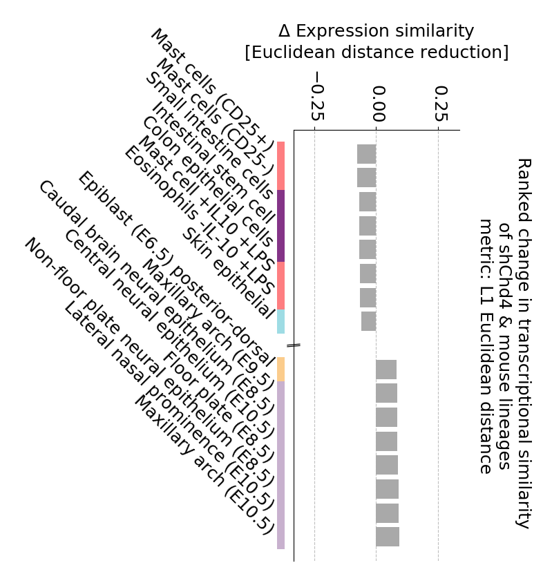

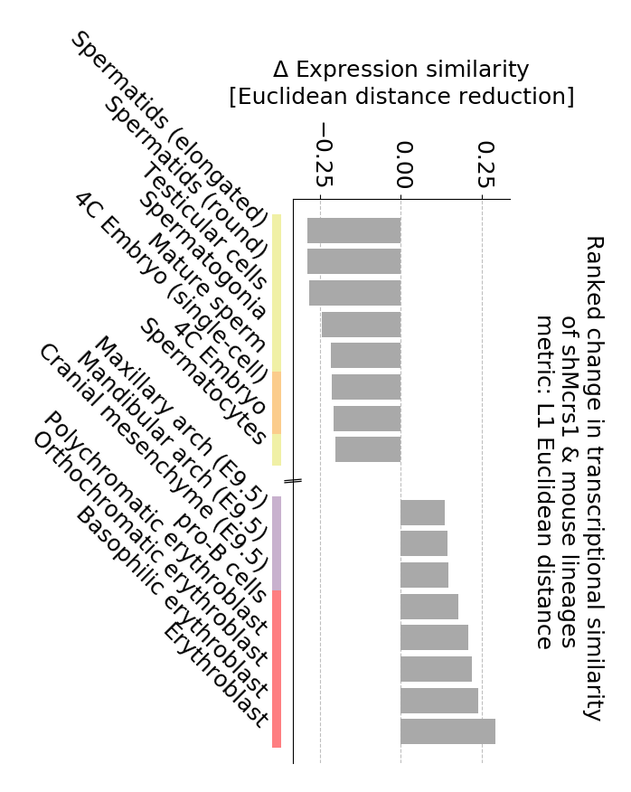

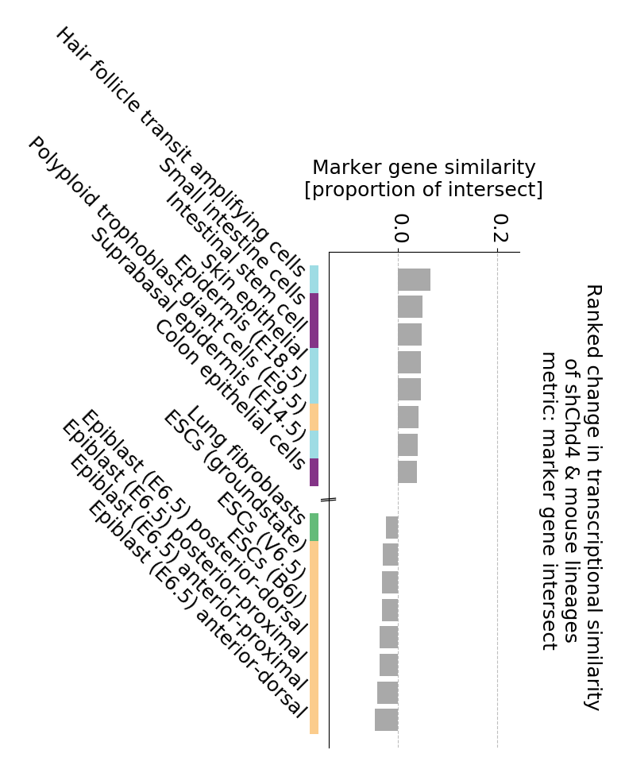

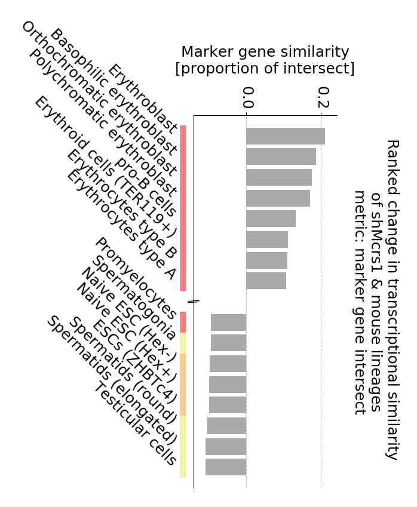

```python
bp = t.ranked_similarity_barplot(samples = s,
                                 metric = 'euclid',
                                 display_negative = True,    # also show the bottom peak values
                                 pivot = True,
                                 filename =  'ranked_sim_eucl.pdf')
bp = t.ranked_similarity_barplot(samples = s,
                                 metric = 'intersect',
                                 display_negative = True,
                                 pivot = True,
                                 filename =  'ranked_sim_intersect.pdf')
```

Or on the command line:

```python
# copy and paste into your terminal
> python ../../dpre.py -pt "mouse" -sd "./knockdown_deseq_res" -se "knockdown_expression.tsv" -c "shLuc" -sn "sh knockdown in mESCs" -so ranked_sim -pi -din -f "ranked_sim_eucl.png"
```

The knockdown of Mcrs1 results in a defined differentiation bias towards Erythroblasts. We can proceed by identifying the driving genes that underlay this bias. We first subset the targets to the different Erythroblasts found in the reference.

```
INFO-DPre slice_elements:
`mouse lineages` sliced:

INFO-DPre _log_init:
=|=|=|=|=|=|=|=|====INITIATION====|=|=|=|=|=|=|=|=|=
New targets-instance created: `mouse lineages`
	targets (5):
		Basophilic erythroblast,
		Erythroblast,
		Orthochromatic erythroblast,
		Polychromatic erythroblast,
		Proerythroblast
	Detected genes: 25075, of which 499 markergenes
	Markergenes loaded: True
	Expression data loaded: True
	Down markergenes loaded: False




INFO-DPre slice_elements:
`sh knockdown in mESCs` sliced:

INFO-DPre _log_init:
=|=|=|=|=|=|=|=|====INITIATION====|=|=|=|=|=|=|=|=|=
New samples-instance created: `sh knockdown in mESCs`
	samples (2):
		shMcrs1,
		shLuc
	Detected genes: 15760, of which 1535 diff. genes
	Differential genes loaded: True
	Expression data loaded: True
	Control passed: shLuc



=|=|=|=|=|=|=|=|====PLOT====|=|=|=|=|=|=|=|=|=
INFO-DPre gene_similarity_heatmap:
Plot: mouse lineages & sh knockdown in mESCs
INFO-DPre _check_args:
```

[output cut: 8 more lines]

```
   Erythroblast                            341                  208    0.609971
Shown are the 4 edge proportion values.

INFO-DPre _compute_similarity:
Computing similarity `euclid` of samples `sh knockdown in mESCs` and targets: `mouse lineages` ...
INFO-DPre _get_similarity:
Selecting and processing overlap data...

INFO-DPre gene_similarity_heatmap:
Drawing...
1/5 --- Basophilic erythroblast
2/5 --- Erythroblast
3/5 --- Orthochromatic erythroblast
4/5 --- Polychromatic erythroblast
5/5 --- Proerythroblast
```

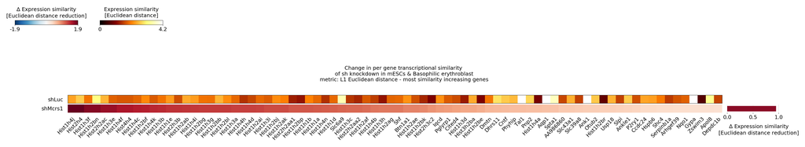

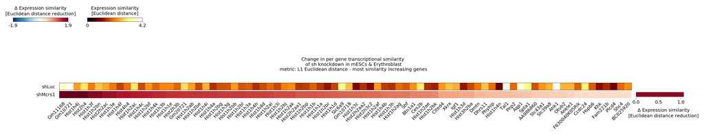

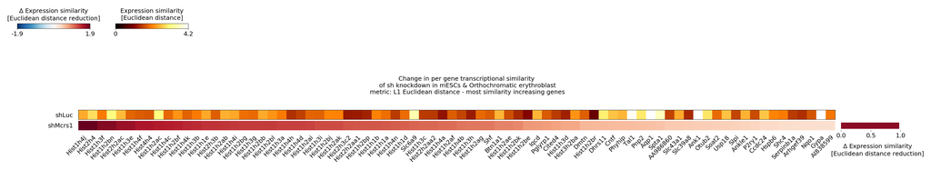

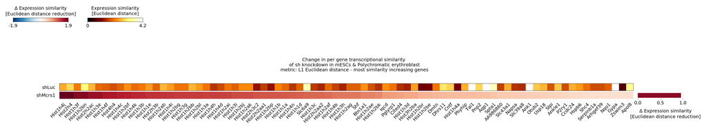

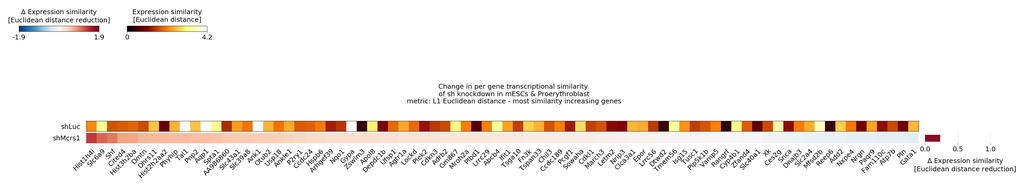

```python
# filter out the erythroblast targets
eryth_names = [n for n in t.names if 'rythroblast' in n]
t_eryth = t.slice_elements(eryth_names)
# drop the Chd4 element from the samples
mcrs4 = s.slice_elements(['shMcrs1', 'shLuc'])

# run the plot without saving to get the returned plot dictionary
gene_sim_plt = t_eryth.gene_similarity_heatmap(mcrs4,
                                               metric = 'euclid',
                                               display_genes = 'increasing',
                                               gene_number = 80,
                                               filename = None,
                                               )
```

The heatmaps reveal that the similarity shift is mainly driven by histone transcripts. We can use the return value of the plot to access the list of genes and assign colors to the different histone types. For this use case and more general data transformations, DPre provides an **annotate()** and **get_ensgs()** functions based on the Ensemble v96 annotation.

```
INFO-DPre plot_color_legend:
Color legend generated and saved at C:\Users\LOaLoA\Anaconda3\Lib\DPre\examples\example2_knockdown/hist_legend.png


=|=|=|=|=|=|=|=|====PLOT====|=|=|=|=|=|=|=|=|=
INFO-DPre gene_similarity_heatmap:
Plot: mouse lineages & sh knockdown in mESCs
INFO-DPre _check_args:
Arguments passed. Getting data now ...
INFO-DPre _get_similarity:
Selecting and processing overlap data...

INFO-DPre gene_similarity_heatmap:
Drawing...
1/5 --- Basophilic erythroblast
2/5 --- Erythroblast
3/5 --- Orthochromatic erythroblast
4/5 --- Polychromatic erythroblast
5/5 --- Proerythroblast
INFO-DPre gene_similarity_heatmap:
Plots saved at C:\Users\LOaLoA\Anaconda3\Lib\DPre\examples\example2_knockdown/gene_sim_incr.pdf
```

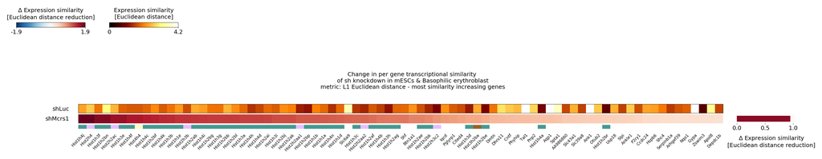

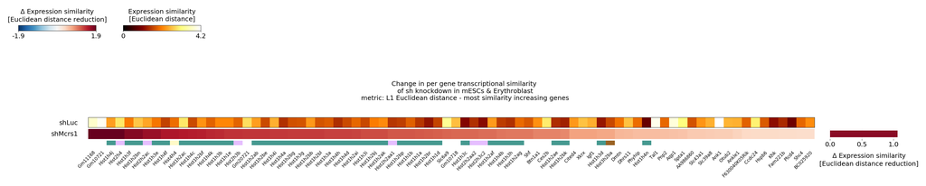

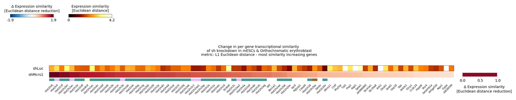

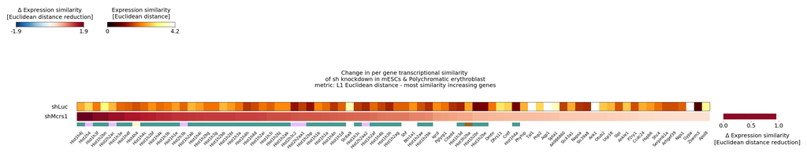

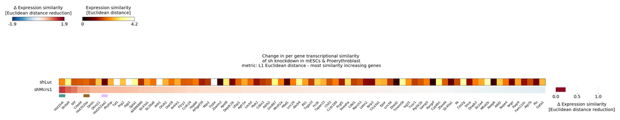

```python
import DPre
# first index the target name,
# then element 3 of [axes, figure, data],
# then 'up' for the marker gene type (only one)
# then element 1 of [heatmap data, distance bar data, sum plot data]
# finally the column names of this DataFrame
genelist = gene_sim_plt['Erythroblast'][2]['up'][0].columns

# annotate the ensg keys
genelist = DPre.annotate(genelist, 'mouse')

# assemble lists containing the specific hist*-groups
hist1 = []
hist2 = []
hist3 = []
hist4 = []
for gene in genelist:
    if gene.startswith('Hist1'):
        hist1.append(gene)
    elif gene.startswith('Hist2'):
        hist2.append(gene)
    elif gene.startswith('Hist3'):
        hist3.append(gene)
    elif gene.startswith('Hist4'):
        hist4.append(gene)

# create a dictionary that maps the gene names to a respective color
hist1_cols = dict.fromkeys(hist1, DPre.config.colors[10])
hist2_cols = dict.fromkeys(hist2, DPre.config.colors[11])
hist3_cols = dict.fromkeys(hist3, DPre.config.colors[12])
hist4_cols = dict.fromkeys(hist4, DPre.config.colors[13])
genes_cb = {**hist1_cols, **hist2_cols, **hist3_cols, **hist4_cols}
# plot the color legend
DPre.plot_color_legend(('Hist1', 'Hist2', 'Hist3', 'Hist4'), DPre.config.colors[10:14],
                       filename='hist_legend.png')

# plot the most increasing genes and save
data = t_eryth.gene_similarity_heatmap(mcrs4,
                                       metric = 'euclid',
                                       display_genes = 'increasing',
                                       gene_number = 80,
                                       heatmap_width = .9,
                                       genelabels_size = .7,
                                       genelabels_space = .5,
                                       show_genes_colorbar = genes_cb,
                                       filename = 'gene_sim_incr.pdf',
                                       HM_WSPACE = .1,           # size constant defining the size between plots (left/right)
                                      )
```

Or on the command line without colors:

```python
# copy and paste into your terminal
!python ../../dpre.py -pt "mouse" -ts "Basophilic erythroblast" -ts "Erythroblast" -ts "Orthochromatic erythroblast" -ts "Polychromatic erythroblast" -ts "Proerythroblast" -sd "./knockdown_deseq_res" -se "knockdown_expression.tsv" -c "shLuc" -sn "sh knockdown in mESCs" -so -ss "shMcrs1" -ss "shLuc" gene_sim -di "increasing" -gn 80 -hw 0.9 -ges 0.7 -ge 0.7 -f "gene_sim_incr.pdf"
```

The gene colorbar emphasizes the dominence of Hist1 nicely.